# Predict Bike Sharing Demand with AutoGluon Template

## Project: Predict Bike Sharing Demand with AutoGluon

This notebook is a template with each step that you need to complete for the project.

Please fill in your code where there are explicit `?` markers in the notebook. You are welcome to add more cells and code as you see fit.

Once you have completed all the code implementations, please export your notebook as a HTML file so the reviews can view your code. Make sure you have all outputs correctly outputted.

`File-> Export Notebook As... -> Export Notebook as HTML`

There is a writeup to complete as well after all code implememtation is done. Please answer all questions and attach the necessary tables and charts. You can complete the writeup in either markdown or PDF.

Completing the code template and writeup template will cover all of the rubric points for this project.

The rubric contains "Stand Out Suggestions" for enhancing the project beyond the minimum requirements. The stand out suggestions are optional. If you decide to pursue the "stand out suggestions", you can include the code in this notebook and also discuss the results in the writeup file.

## Step 1: Create an account with Kaggle

### Create Kaggle Account and download API key

Below is example of steps to get the API username and key. Each student will have their own username and key.

1. Open account settings.

2. Scroll down to API and click Create New API Token.

3. Open up `kaggle.json` and use the username and key.


## Step 2: Download the Kaggle dataset using the kaggle python library

### Open up Sagemaker Studio and use starter template

1. Notebook should be using a `ml.t3.medium` instance (2 vCPU + 4 GiB)
2. Notebook should be using kernal: `Python 3 (MXNet 1.8 Python 3.7 CPU Optimized)`

### Install packages

```python
!pip install kaggle
```

### Setup Kaggle API Key

```python
# Fill in your user name and key from creating the kaggle account and API token file
import json
kaggle_username = "####"
kaggle_key = "####"

# Save API token the kaggle.json file
with open("kaggle.json", "w") as f:
    f.write(json.dumps({"username": kaggle_username, "key": kaggle_key}))
```

### Download and explore dataset

### Go to the bike sharing demand competition and agree to the terms

```python
# Download the dataset, it will be in a .zip file so you'll need to unzip it as well.
!kaggle competitions download -c bike-sharing-demand
# If you already downloaded it you can use the -o command to overwrite the file
!unzip -o bike-sharing-demand.zip
```

```
Downloading bike-sharing-demand.zip to C:\Users\Nader\JupyterNotes\AWS\Project 1\cd0385-project-starter
```

[output not shown]

```python
import pandas as pd
from autogluon.tabular import TabularPredictor
```

```python
# Create the train dataset in pandas by reading the csv
# Set the parsing of the datetime column so you can use some of the `dt` features in pandas later
train = pd.read_csv('../DataSets/train.csv')
train['datetime'] = pd.to_datetime(train['datetime'])
train.drop(['casual' , 'registered'] , axis = 1 , inplace = True)
train.head()
```

|  | datetime | season | holiday | workingday | weather | temp | atemp | humidity | windspeed | count |
| --- | --- | --- | --- | --- | --- | --- | --- | --- | --- | --- |
| 0 | 2011-01-01 00:00:00 | 1 | 0 | 0 | 1 | 9.84 | 14.395 | 81 | 0.0 | 16 |
| 1 | 2011-01-01 01:00:00 | 1 | 0 | 0 | 1 | 9.02 | 13.635 | 80 | 0.0 | 40 |
| 2 | 2011-01-01 02:00:00 | 1 | 0 | 0 | 1 | 9.02 | 13.635 | 80 | 0.0 | 32 |
| 3 | 2011-01-01 03:00:00 | 1 | 0 | 0 | 1 | 9.84 | 14.395 | 75 | 0.0 | 13 |
| 4 | 2011-01-01 04:00:00 | 1 | 0 | 0 | 1 | 9.84 | 14.395 | 75 | 0.0 | 1 |

```python
# Simple output of the train dataset to view some of the min/max/varition of the dataset features.
train.info()
```

```
<class 'pandas.core.frame.DataFrame'>
RangeIndex: 10886 entries, 0 to 10885
Data columns (total 10 columns):
 #   Column      Non-Null Count  Dtype
---  ------      --------------  -----
 0   datetime    10886 non-null  datetime64[ns]
 1   season      10886 non-null  int64
 2   holiday     10886 non-null  int64
 3   workingday  10886 non-null  int64
 4   weather     10886 non-null  int64
 5   temp        10886 non-null  float64
 6   atemp       10886 non-null  float64
 7   humidity    10886 non-null  int64
 8   windspeed   10886 non-null  float64
 9   count       10886 non-null  int64
dtypes: datetime64[ns](1), float64(3), int64(6)
memory usage: 850.6 KB
```

```python
# Create the test pandas dataframe in pandas by reading the csv, remember to parse the datetime!
test = pd.read_csv('../DataSets/test.csv')
test['datetime'] = pd.to_datetime(test['datetime'])
test.head()
```

|  | datetime | season | holiday | workingday | weather | temp | atemp | humidity | windspeed |
| --- | --- | --- | --- | --- | --- | --- | --- | --- | --- |
| 0 | 2011-01-20 00:00:00 | 1 | 0 | 1 | 1 | 10.66 | 11.365 | 56 | 26.0027 |
| 1 | 2011-01-20 01:00:00 | 1 | 0 | 1 | 1 | 10.66 | 13.635 | 56 | 0.0000 |
| 2 | 2011-01-20 02:00:00 | 1 | 0 | 1 | 1 | 10.66 | 13.635 | 56 | 0.0000 |
| 3 | 2011-01-20 03:00:00 | 1 | 0 | 1 | 1 | 10.66 | 12.880 | 56 | 11.0014 |
| 4 | 2011-01-20 04:00:00 | 1 | 0 | 1 | 1 | 10.66 | 12.880 | 56 | 11.0014 |

```python
# Same thing as train and test dataset
submission = pd.read_csv('../DataSets/sampleSubmission.csv')
submission['datetime'] = pd.to_datetime(submission['datetime'])
submission.head()
```

|  | datetime | count |
| --- | --- | --- |
| 0 | 2011-01-20 00:00:00 | 0 |
| 1 | 2011-01-20 01:00:00 | 0 |
| 2 | 2011-01-20 02:00:00 | 0 |
| 3 | 2011-01-20 03:00:00 | 0 |
| 4 | 2011-01-20 04:00:00 | 0 |

## Step 3: Train a model using AutoGluon’s Tabular Prediction

Requirements:

- We are prediting `count`, so it is the label we are setting.
- Ignore `casual` and `registered` columns as they are also not present in the test dataset.
- Use the `root_mean_squared_error` as the metric to use for evaluation.
- Set a time limit of 10 minutes (600 seconds).
- Use the preset `best_quality` to focus on creating the best model.

```python
predictor = TabularPredictor('count' , eval_metric="root_mean_squared_error").fit(train_data = train , time_limit=600, presets="best_quality")
```

### Review AutoGluon's training run with ranking of models that did the best.

```python
predictor.fit_summary()
```

```
*** Summary of fit() ***
Estimated performance of each model:
                     model   score_val  pred_time_val    fit_time  pred_time_val_marginal  fit_time_marginal  stack_level  can_infer  fit_order
0      WeightedEnsemble_L3  -50.569302      12.910456  418.427067                0.000000           0.336030            3       True         21
1   NeuralNetFastAI_BAG_L2  -51.661135      11.889157  403.711809                0.309025          46.291274            2       True         18
2   RandomForestMSE_BAG_L2  -53.474544      12.065560  368.350374                0.485428          10.929839            2       True         15
3     ExtraTreesMSE_BAG_L2  -53.984347      12.116004  360.869925                0.535872           3.449389            2       True         17
4          LightGBM_BAG_L2  -55.035615      11.811285  373.741479                0.231153          16.320943            2       True         14
5           XGBoost_BAG_L2  -55.101711      11.665135  372.350812                0.085003          14.930276            2       True         19
6          CatBoost_BAG_L2  -55.822784      11.621122  404.437643                0.040990          47.017107            2       True         16
7        LightGBMXT_BAG_L2  -60.391403      15.409735  382.776731                3.829603          25.356195            2       True         13
8    NeuralNetTorch_BAG_L2  -82.869059      11.904046  372.118745                0.323914          14.698209            2       True         20
9      WeightedEnsemble_L2  -84.146423       0.018994    0.441863                0.000000           0.371885            2       True         12
10   KNeighborsDist_BAG_L1  -84.146423       0.018994    0.069978                0.018994           0.069978            1       True          2
11   KNeighborsUnif_BAG_L1 -101.588176       0.020993    0.071977                0.020993           0.071977            1       True          1
12  RandomForestMSE_BAG_L1 -116.543822       0.424874    3.396554                0.424874           3.396554            1       True          5
13    ExtraTreesMSE_BAG_L1 -124.594043       0.412333    1.774715                0.412333           1.774715            1       True          7
14    LightGBMLarge_BAG_L1 -130.132290       0.582010   11.083295                0.582010          11.083295            1       True         11
15         CatBoost_BAG_L1 -130.461205       0.098984  147.780971                0.098984         147.780971            1       True          6
16         LightGBM_BAG_L1 -131.054162       0.960951   13.361378                0.960951          13.361378            1       True          4
17       LightGBMXT_BAG_L1 -131.460909       8.433699   24.359801                8.433699          24.359801            1       True          3
18          XGBoost_BAG_L1 -131.624665       0.185009   12.046873                0.185009          12.046873            1       True          9
19  NeuralNetFastAI_BAG_L1 -135.849413       0.258508   34.635490                0.258508          34.635490            1       True          8
20   NeuralNetTorch_BAG_L1 -138.226220       0.183777  108.839506                0.183777         108.839506            1       True         10
Number of models trained: 21
Types of models trained:
{'StackerEnsembleModel_CatBoost', 'StackerEnsembleModel_TabularNeuralNetTorch', 'WeightedEnsembleModel', 'StackerEnsembleModel_LGB', 'StackerEnsembleModel_KNN', 'StackerEnsembleModel_RF', 'StackerEnsembleModel_XT', 'StackerEnsembleModel_NNFastAiTabular', 'StackerEnsembleModel_XGBoost'}
Bagging used: True  (with 8 folds)
Multi-layer stack-ensembling used: True  (with 3 levels)
Feature Metadata (Processed):
(raw dtype, special dtypes):
('float', [])                : 3 | ['temp', 'atemp', 'windspeed']
('int', [])                  : 3 | ['season', 'weather', 'humidity']
('int', ['bool'])            : 2 | ['holiday', 'workingday']
('int', ['datetime_as_int']) : 5 | ['datetime', 'datetime.year', 'datetime.month', 'datetime.day', 'datetime.dayofweek']
Plot summary of models saved to file: AutogluonModels/ag-20220729_130559\SummaryOfModels.html
*** End of fit() summary ***
```

[output not shown]

[output cut: 211 more lines]

```
 6          16
 7          13
 8          20
 9          12
 10          2
 11          1
 12          5
 13          7
 14         11
 15          6
 16          4
 17          3
 18          9
 19          8
 20         10  }
```

### Create predictions from test dataset

```python
predictions = predictor.predict(test)
predictions.head()
```

```
0    24.933002
1    41.399929
2    46.101112
3    49.282639
4    51.396404
Name: count, dtype: float32
```

#### NOTE: Kaggle will reject the submission if we don't set everything to be > 0.

```python
# Describe the `predictions` series to see if there are any negative values
predictions.describe()
```

```
count    6493.000000
mean      100.363861
std        87.912727
min         1.729862
25%        22.284538
50%        68.759567
75%       168.948029
max       349.833344
Name: count, dtype: float64
```

```python
# How many negative values do we have? # Set them to zero
predictions[predictions < 0 ] = 0
```

### Set predictions to submission dataframe, save, and submit

```python
submission["count"] = predictions
submission.to_csv("submission.csv", index=False)
```

```python
!kaggle competitions submit -c bike-sharing-demand -f submission.csv -m "Another raw submission"
```

```
Successfully submitted to Bike Sharing Demand
```

```
  4%|4         | 8.00k/195k [00:00<00:03, 62.8kB/s]
 49%|####9     | 96.0k/195k [00:00<00:00, 479kB/s]
 99%|#########8| 192k/195k [00:00<00:00, 676kB/s]
```

#### View submission via the command line or in the web browser under the competition's page - `My Submissions`

```python
!kaggle competitions submissions -c bike-sharing-demand
```

```
fileName                     date                 description                        status    publicScore  privateScore
---------------------------  -------------------  ---------------------------------  --------  -----------  ------------
submission.csv               2022-07-29 13:22:52  Another raw submission             complete  1.77919      1.77919
submission_new_hpo.csv       2022-07-28 20:51:44  new features with hyperparameters  complete  0.47178      0.47178
submission_new_hpo.csv       2022-07-28 20:31:02  new features with hyperparameters  complete  0.76074      0.76074
submission_new_hpo.csv       2022-07-28 19:58:03  new features with hyperparameters  complete  0.77419      0.77419
submission_new_features.csv  2022-07-28 01:03:47  new features                       complete  0.46527      0.46527
submission.csv               2022-07-27 23:54:52  first raw submission               complete  1.81132      1.81132
submission.csv               2022-07-27 23:51:16  first raw submission               complete  1.81132      1.81132
```

#### Initial score of `1.77919`

## Step 4: Exploratory Data Analysis and Creating an additional feature

- Any additional feature will do, but a great suggestion would be to separate out the datetime into hour, day, or month parts.

```python
import matplotlib.pyplot as plt
import numpy as np
import seaborn as sns; sns.set_theme()
```

```python
train.head()
```

|  | datetime | season | holiday | workingday | weather | temp | atemp | humidity | windspeed | count |
| --- | --- | --- | --- | --- | --- | --- | --- | --- | --- | --- |
| 0 | 2011-01-01 00:00:00 | 1 | 0 | 0 | 1 | 9.84 | 14.395 | 81 | 0.0 | 16 |
| 1 | 2011-01-01 01:00:00 | 1 | 0 | 0 | 1 | 9.02 | 13.635 | 80 | 0.0 | 40 |
| 2 | 2011-01-01 02:00:00 | 1 | 0 | 0 | 1 | 9.02 | 13.635 | 80 | 0.0 | 32 |
| 3 | 2011-01-01 03:00:00 | 1 | 0 | 0 | 1 | 9.84 | 14.395 | 75 | 0.0 | 13 |
| 4 | 2011-01-01 04:00:00 | 1 | 0 | 0 | 1 | 9.84 | 14.395 | 75 | 0.0 | 1 |

```python
train.describe()
```

|  | season | holiday | workingday | weather | temp | atemp | humidity | windspeed | count |
| --- | --- | --- | --- | --- | --- | --- | --- | --- | --- |
| count | 10886.000000 | 10886.000000 | 10886.000000 | 10886.000000 | 10886.00000 | 10886.000000 | 10886.000000 | 10886.000000 | 10886.000000 |
| mean | 2.506614 | 0.028569 | 0.680875 | 1.418427 | 20.23086 | 23.655084 | 61.886460 | 12.799395 | 191.574132 |
| std | 1.116174 | 0.166599 | 0.466159 | 0.633839 | 7.79159 | 8.474601 | 19.245033 | 8.164537 | 181.144454 |
| min | 1.000000 | 0.000000 | 0.000000 | 1.000000 | 0.82000 | 0.760000 | 0.000000 | 0.000000 | 1.000000 |
| 25% | 2.000000 | 0.000000 | 0.000000 | 1.000000 | 13.94000 | 16.665000 | 47.000000 | 7.001500 | 42.000000 |
| 50% | 3.000000 | 0.000000 | 1.000000 | 1.000000 | 20.50000 | 24.240000 | 62.000000 | 12.998000 | 145.000000 |
| 75% | 4.000000 | 0.000000 | 1.000000 | 2.000000 | 26.24000 | 31.060000 | 77.000000 | 16.997900 | 284.000000 |
| max | 4.000000 | 1.000000 | 1.000000 | 4.000000 | 41.00000 | 45.455000 | 100.000000 | 56.996900 | 977.000000 |

```
No handles with labels found to put in legend.
```

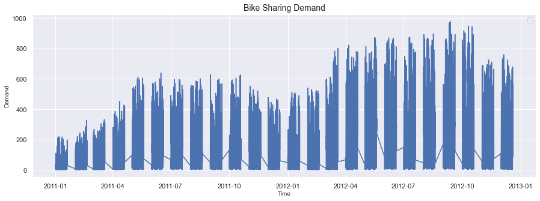

```python
# TimeSeries Plotting
# Set the notebook to display matplotlib charts inline:
%matplotlib inline
# set a figure of size (15,5):
fig = plt.figure(figsize = (15,5))
# plot the Henry Hub values with a dashed blue line, width 2:
plt.plot(train['datetime'], train['count'])
# set the plot title:
plt.title('Bike Sharing Demand', fontsize=14)
# set the x-axis label:
plt.xlabel('Time',fontsize=10)
# set the y-axis label:
plt.ylabel('Demand',fontsize=10)
# add a legend to the plot:
plt.legend()
# show the chart:
plt.show();
```

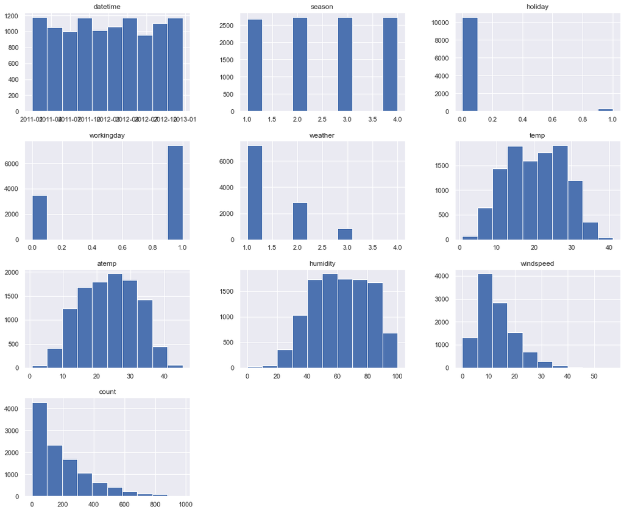

```python
# Create a histogram of all features to show the distribution of each one relative to the data. This is part of the exploritory data analysis
train.hist(figsize = [18 , 15]);
```

```python
train['year'] = train.datetime.dt.year
train['Month'] = train.datetime.dt.month
train['Day'] = train.datetime.dt.day
train['Hour'] = train.datetime.dt.hour
train.head()
train_v2 = train.drop(['datetime'] , axis = 1)
```

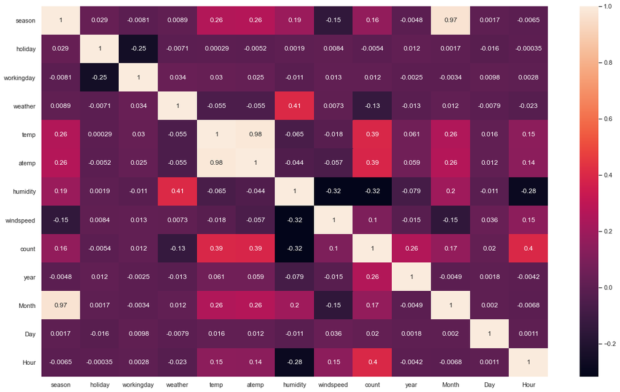

```python
correlation_mat = train_v2.corr()
plt.figure(figsize=[20, 12])
sns.heatmap(correlation_mat , annot=True)
```

```python
# create a new feature
test['year'] = test.datetime.dt.year
test['Month'] = test.datetime.dt.month
test['Day'] = test.datetime.dt.day
test['Hour'] = test.datetime.dt.hour
test_v2 = test.drop(['datetime'] , axis = 1)
test_v2
```

|  | season | holiday | workingday | weather | temp | atemp | humidity | windspeed | year | Month | Day | Hour |
| --- | --- | --- | --- | --- | --- | --- | --- | --- | --- | --- | --- | --- |
| 0 | 1 | 0 | 1 | 1 | 10.66 | 11.365 | 56 | 26.0027 | 2011 | 1 | 20 | 0 |
| 1 | 1 | 0 | 1 | 1 | 10.66 | 13.635 | 56 | 0.0000 | 2011 | 1 | 20 | 1 |
| 2 | 1 | 0 | 1 | 1 | 10.66 | 13.635 | 56 | 0.0000 | 2011 | 1 | 20 | 2 |
| 3 | 1 | 0 | 1 | 1 | 10.66 | 12.880 | 56 | 11.0014 | 2011 | 1 | 20 | 3 |
| 4 | 1 | 0 | 1 | 1 | 10.66 | 12.880 | 56 | 11.0014 | 2011 | 1 | 20 | 4 |
| ... | ... | ... | ... | ... | ... | ... | ... | ... | ... | ... | ... | ... |
| 6488 | 1 | 0 | 1 | 2 | 10.66 | 12.880 | 60 | 11.0014 | 2012 | 12 | 31 | 19 |
| 6489 | 1 | 0 | 1 | 2 | 10.66 | 12.880 | 60 | 11.0014 | 2012 | 12 | 31 | 20 |
| 6490 | 1 | 0 | 1 | 1 | 10.66 | 12.880 | 60 | 11.0014 | 2012 | 12 | 31 | 21 |
| 6491 | 1 | 0 | 1 | 1 | 10.66 | 13.635 | 56 | 8.9981 | 2012 | 12 | 31 | 22 |
| 6492 | 1 | 0 | 1 | 1 | 10.66 | 13.635 | 65 | 8.9981 | 2012 | 12 | 31 | 23 |

6493 rows × 12 columns

## Make category types for these so models know they are not just numbers

- AutoGluon originally sees these as ints, but in reality they are int representations of a category.
- Setting the dtype to category will classify these as categories in AutoGluon.

```python
train_v2["season"] = train_v2.season.astype('category')
train_v2["weather"] = train_v2.weather.astype('category')
test_v2["season"] = test_v2.season.astype('category')
test_v2["weather"] = test_v2.weather.astype('category')
```

```python
train_v2.info()
```

```
<class 'pandas.core.frame.DataFrame'>
RangeIndex: 10886 entries, 0 to 10885
Data columns (total 13 columns):
 #   Column      Non-Null Count  Dtype
---  ------      --------------  -----
 0   season      10886 non-null  category
 1   holiday     10886 non-null  int64
 2   workingday  10886 non-null  int64
 3   weather     10886 non-null  category
 4   temp        10886 non-null  float64
 5   atemp       10886 non-null  float64
 6   humidity    10886 non-null  int64
 7   windspeed   10886 non-null  float64
 8   count       10886 non-null  int64
 9   year        10886 non-null  int64
 10  Month       10886 non-null  int64
 11  Day         10886 non-null  int64
 12  Hour        10886 non-null  int64
dtypes: category(2), float64(3), int64(8)
memory usage: 957.3 KB
```

```python
# View are new feature
train_v2.head()
```

|  | season | holiday | workingday | weather | temp | atemp | humidity | windspeed | count | year | Month | Day | Hour |
| --- | --- | --- | --- | --- | --- | --- | --- | --- | --- | --- | --- | --- | --- |
| 0 | 1 | 0 | 0 | 1 | 9.84 | 14.395 | 81 | 0.0 | 16 | 2011 | 1 | 1 | 0 |
| 1 | 1 | 0 | 0 | 1 | 9.02 | 13.635 | 80 | 0.0 | 40 | 2011 | 1 | 1 | 1 |
| 2 | 1 | 0 | 0 | 1 | 9.02 | 13.635 | 80 | 0.0 | 32 | 2011 | 1 | 1 | 2 |
| 3 | 1 | 0 | 0 | 1 | 9.84 | 14.395 | 75 | 0.0 | 13 | 2011 | 1 | 1 | 3 |
| 4 | 1 | 0 | 0 | 1 | 9.84 | 14.395 | 75 | 0.0 | 1 | 2011 | 1 | 1 | 4 |

```
No handles with labels found to put in legend.
```

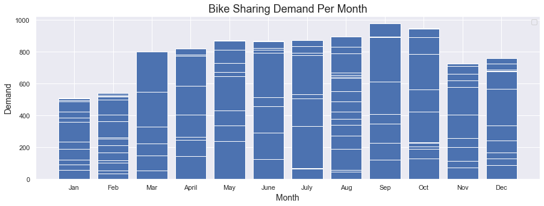

```python
# TimeSeries Plotting
# Magic Line
%matplotlib inline
# set a figure of size (15,5):
fig = plt.figure(figsize = (15,5))
# plot the Henry Hub values with a dashed blue line, width 2:
plt.bar(train_v2['Month'], train_v2['count'] , data = train_v2['year'])
# Assign Labels
Months = ['Jan' , 'Feb' , 'Mar' , 'April' , 'May' , 'June' , 'July' , 'Aug' , 'Sep' , 'Oct' , 'Nov' , 'Dec']
plt.xticks(train_v2['Month'].unique() , labels = Months)
# set the plot title:
plt.title('Bike Sharing Demand Per Month', fontsize=18)
# set the x-axis label:
plt.xlabel('Month',fontsize=14)
# set the y-axis label:
plt.ylabel('Demand',fontsize=14)
# add a legend to the plot:
plt.legend()
# show the chart:
plt.show();
```

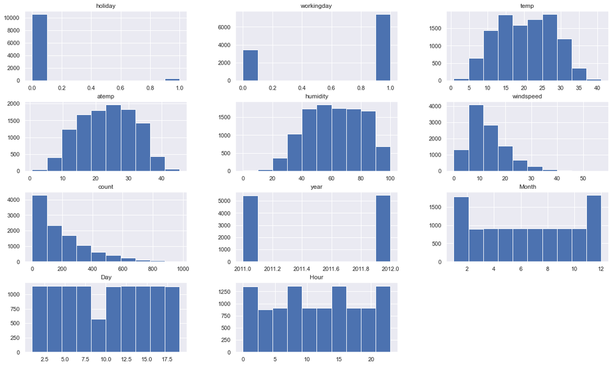

```python
# View histogram of all features again now with the hour feature
train_v2.hist(figsize=[20,12]);
```

## Step 5: Rerun the model with the same settings as before, just with more features

```python
predictor_new_features = TabularPredictor('count' , eval_metric="root_mean_squared_error").fit(train_data = train_v2 , time_limit = 600 , presets = "best_quality")
```

```python
predictor_new_features.fit_summary()
```

```
*** Summary of fit() ***
Estimated performance of each model:
                     model   score_val  pred_time_val    fit_time  pred_time_val_marginal  fit_time_marginal  stack_level  can_infer  fit_order
0      WeightedEnsemble_L3  -35.780223      25.957798  533.785094                0.000000           0.284908            3       True         19
1      WeightedEnsemble_L2  -35.883737      22.997977  325.565750                0.000000           0.305925            2       True         10
2     ExtraTreesMSE_BAG_L2  -36.147540      24.854933  381.877727                0.477888           2.875393            2       True         15
3          LightGBM_BAG_L2  -36.260465      24.461034  388.815549                0.083989           9.813215            2       True         12
4          CatBoost_BAG_L2  -36.363646      24.453022  457.204882                0.075977          78.202548            2       True         14
5   NeuralNetFastAI_BAG_L2  -36.419617      24.722036  421.266632                0.344991          42.264298            2       True         16
6           XGBoost_BAG_L2  -36.478608      24.481555  391.522672                0.104510          12.520338            2       True         17
7   RandomForestMSE_BAG_L2  -36.665264      24.870442  387.824393                0.493397           8.822059            2       True         13
8        LightGBMXT_BAG_L2  -36.971454      24.610023  388.783179                0.232978           9.780845            2       True         11
9        LightGBMXT_BAG_L1  -37.097828      18.054369   30.372212               18.054369          30.372212            1       True          3
10         LightGBM_BAG_L1  -37.692850       4.299215   16.287823                4.299215          16.287823            1       True          4
11         CatBoost_BAG_L1  -38.072119       0.115985  275.197876                0.115985         275.197876            1       True          6
12          XGBoost_BAG_L1  -39.263127       0.467938   14.743471                0.467938          14.743471            1       True          9
13    ExtraTreesMSE_BAG_L1  -41.620336       0.446191    1.712878                0.446191           1.712878            1       True          7
14  RandomForestMSE_BAG_L1  -42.149734       0.528408    3.401914                0.528408           3.401914            1       True          5
15   NeuralNetTorch_BAG_L2  -42.194663      24.674082  391.751547                0.297037          12.749213            2       True         18
16  NeuralNetFastAI_BAG_L1  -47.715174       0.273000   37.193191                0.273000          37.193191            1       True          8
17   KNeighborsDist_BAG_L1 -119.358812       0.096970    0.042986                0.096970           0.042986            1       True          2
18   KNeighborsUnif_BAG_L1 -123.919678       0.094970    0.049984                0.094970           0.049984            1       True          1
Number of models trained: 19
Types of models trained:
{'StackerEnsembleModel_CatBoost', 'StackerEnsembleModel_TabularNeuralNetTorch', 'WeightedEnsembleModel', 'StackerEnsembleModel_LGB', 'StackerEnsembleModel_KNN', 'StackerEnsembleModel_RF', 'StackerEnsembleModel_XT', 'StackerEnsembleModel_NNFastAiTabular', 'StackerEnsembleModel_XGBoost'}
Bagging used: True  (with 8 folds)
Multi-layer stack-ensembling used: True  (with 3 levels)
Feature Metadata (Processed):
(raw dtype, special dtypes):
('category', [])  : 2 | ['season', 'weather']
('float', [])     : 3 | ['temp', 'atemp', 'windspeed']
('int', [])       : 4 | ['humidity', 'Month', 'Day', 'Hour']
('int', ['bool']) : 3 | ['holiday', 'workingday', 'year']
Plot summary of models saved to file: AutogluonModels/ag-20220729_132620\SummaryOfModels.html
*** End of fit() summary ***
```

[output not shown]

[output cut: 187 more lines]

```
 4          14
 5          16
 6          17
 7          13
 8          11
 9           3
 10          4
 11          6
 12          9
 13          7
 14          5
 15         18
 16          8
 17          2
 18          1  }
```

```python
#Create predictions from test dataset
predictions_v2 = predictor_new_features.predict(test_v2)
predictions_v2.head()
```

```
0    12.975025
1     5.233331
2     4.315054
3     4.180796
4     4.085693
Name: count, dtype: float32
```

```python
# Remember to set all negative values to zero
predictions_v2[predictions_v2 < 0] = 0
```

```python
submission.to_csv('submission_new_features.csv' , index=False)
```

```python
# Same submitting predictions
submission_new_features = pd.read_csv('submission_new_features.csv')
submission_new_features["count"] = predictions_v2
submission_new_features.to_csv("submission_new_features.csv", index=False)
```

```python
!kaggle competitions submit -c bike-sharing-demand -f submission_new_features.csv -m "Local new features"
```

```
Successfully submitted to Bike Sharing Demand
```

```
  4%|4         | 8.00k/194k [00:00<00:03, 62.4kB/s]
 49%|####9     | 96.0k/194k [00:00<00:00, 478kB/s]
 99%|#########8| 192k/194k [00:00<00:00, 671kB/s]
```

```python
!kaggle competitions submissions -c bike-sharing-demand
```

```
fileName                     date                 description                        status    publicScore  privateScore
---------------------------  -------------------  ---------------------------------  --------  -----------  ------------
submission_new_features.csv  2022-07-29 13:49:06  Local new features                 complete  0.45618      0.45618
submission.csv               2022-07-29 13:22:52  Another raw submission             complete  1.77919      1.77919
submission_new_hpo.csv       2022-07-28 20:51:44  new features with hyperparameters  complete  0.47178      0.47178
submission_new_hpo.csv       2022-07-28 20:31:02  new features with hyperparameters  complete  0.76074      0.76074
submission_new_hpo.csv       2022-07-28 19:58:03  new features with hyperparameters  complete  0.77419      0.77419
submission_new_features.csv  2022-07-28 01:03:47  new features                       complete  0.46527      0.46527
submission.csv               2022-07-27 23:54:52  first raw submission               complete  1.81132      1.81132
submission.csv               2022-07-27 23:51:16  first raw submission               complete  1.81132      1.81132
```

#### New Score of `0.45618`

## Model Performance

```python
# Calculate Model Performance Enhancement
new_score = 0.45618
old_score = 1.77919
Improvment_Percentage = (1 - (new_score / old_score) ) * 100
print('Model Score improved by {:.2f}% from the last model'.format(Improvment_Percentage))
```

```
Model Score improved by 74.36% from the last model
```

> So we can see that the model accuracy increased by a **74.36%** by adding new features such as HOURS

## Step 6: Hyper parameter optimization

- There are many options for hyper parameter optimization.
- Options are to change the AutoGluon higher level parameters or the individual model hyperparameters.
- The hyperparameters of the models themselves that are in AutoGluon. Those need the `hyperparameter` and `hyperparameter_tune_kwargs` arguments.
- Remove unwanted features that could affect model score >> **holiday , weather , humidity**

```python
train_v3 = train_v2.drop(['holiday' , 'weather' , 'humidity'] , axis = 1)
```

```python
train_v3.head()
```

|  | season | workingday | temp | atemp | windspeed | count | year | Month | Day | Hour |
| --- | --- | --- | --- | --- | --- | --- | --- | --- | --- | --- |
| 0 | 1 | 0 | 9.84 | 14.395 | 0.0 | 16 | 2011 | 1 | 1 | 0 |
| 1 | 1 | 0 | 9.02 | 13.635 | 0.0 | 40 | 2011 | 1 | 1 | 1 |
| 2 | 1 | 0 | 9.02 | 13.635 | 0.0 | 32 | 2011 | 1 | 1 | 2 |
| 3 | 1 | 0 | 9.84 | 14.395 | 0.0 | 13 | 2011 | 1 | 1 | 3 |
| 4 | 1 | 0 | 9.84 | 14.395 | 0.0 | 1 | 2011 | 1 | 1 | 4 |

```python
test_v3 = test_v2.drop(['holiday' , 'weather' , 'humidity'] , axis = 1)
test_v3.head()
```

|  | season | workingday | temp | atemp | windspeed | year | Month | Day | Hour |
| --- | --- | --- | --- | --- | --- | --- | --- | --- | --- |
| 0 | 1 | 1 | 10.66 | 11.365 | 26.0027 | 2011 | 1 | 20 | 0 |
| 1 | 1 | 1 | 10.66 | 13.635 | 0.0000 | 2011 | 1 | 20 | 1 |
| 2 | 1 | 1 | 10.66 | 13.635 | 0.0000 | 2011 | 1 | 20 | 2 |
| 3 | 1 | 1 | 10.66 | 12.880 | 11.0014 | 2011 | 1 | 20 | 3 |
| 4 | 1 | 1 | 10.66 | 12.880 | 11.0014 | 2011 | 1 | 20 | 4 |

```python
import autogluon.core as ag

nn_options = {# specifies non-default hyperparameter values for neural network models
    'num_epochs': 10,
    'learning_rate': ag.space.Real(1e-4, 1e-2, default=5e-4, log=True),
    'activation': ag.space.Categorical('relu', 'softrelu', 'tanh'),
    'layers': ag.space.Categorical([100], [1000], [200, 100], [300, 200, 100]),
    'dropout_prob': ag.space.Real(0.0, 0.5, default=0.1),
}

gbm_options = {  # specifies non-default hyperparameter values for lightGBM gradient boosted trees
    'num_boost_round': 100,
    'num_leaves': ag.space.Int(lower=26, upper=66, default=36),
}

hyperparameters = {
                   'GBM': gbm_options,
                   'NN': nn_options,
                  }

hyperparameter_tune_kwargs = {  # HPO is not performed unless hyperparameter_tune_kwargs is specified
    'scheduler' : 'local',
    'searcher': 'auto',
}
```

```python
predictor_new_hpo = TabularPredictor('count' , eval_metric="root_mean_squared_error").fit(train_data = train_v3 , time_limit = 600 , presets = "best_quality" , hyperparameters = hyperparameters , hyperparameter_tune_kwargs = hyperparameter_tune_kwargs)
```

```python
predictor_new_hpo.fit_summary()
```

```
*** Summary of fit() ***
Estimated performance of each model:
                   model   score_val  pred_time_val    fit_time  pred_time_val_marginal  fit_time_marginal  stack_level  can_infer  fit_order
0    WeightedEnsemble_L3  -44.094050       3.027952  258.890653                0.000999           0.200937            3       True        112
1     LightGBM_BAG_L2\T1  -44.246473       2.772038  229.270967                0.089971           8.650210            2       True         88
2    LightGBM_BAG_L2\T13  -44.262832       2.757035  227.491567                0.074968           6.870809            2       True        100
3     LightGBM_BAG_L2\T7  -44.305700       2.746045  227.068841                0.063978           6.448084            2       True         94
4    LightGBM_BAG_L2\T10  -44.350182       2.723067  227.628513                0.041000           7.007756            2       True         97
5     LightGBM_BAG_L2\T2  -44.451002       2.757037  229.712858                0.074970           9.092100            2       True         89
6     LightGBM_BAG_L2\T3  -44.472442       2.786035  228.567227                0.103968           7.946470            2       True         90
7     LightGBM_BAG_L2\T8  -44.489929       2.740068  228.400265                0.058001           7.779507            2       True         95
8     LightGBM_BAG_L2\T5  -44.593965       2.765038  228.210323                0.082971           7.589566            2       True         92
9    WeightedEnsemble_L2  -44.864080       0.254889   19.512924                0.000999           0.190951            2       True         87
10   LightGBM_BAG_L1\T34  -45.395049       0.085976    6.386596                0.085976           6.386596            1       True         34
11   LightGBM_BAG_L1\T22  -45.536832       0.082957    6.737556                0.082957           6.737556            1       True         22
```

[output cut: 113 more lines]

[output not shown]

[output cut: 996 more lines]

```

      fit_order
 0          112
 1           88
 2          100
 3           94
 4           97
 ..         ...
 107          4
 108         12
 109         53
 110         80
 111         29

 [112 rows x 9 columns]}
```

```python
predictions_v3 = predictor_new_hpo.predict(test_v3)
predictions_v3.head()
```

```
0    11.760033
1     8.844765
2     8.800926
3     8.800926
4     8.800926
Name: count, dtype: float32
```

```python
# Remember to set all negative values to zero
predictions_v3[predictions_v3 < 0] = 0
```

```python
# Same submitting predictions
submission.to_csv("submission_new_hpo.csv", index=False)
submission_new_hpo = pd.read_csv('submission_new_hpo.csv')
submission_new_hpo["count"] = predictions_v3
submission_new_hpo.to_csv("submission_new_hpo.csv", index=False)
```

```python
!kaggle competitions submit -c bike-sharing-demand -f submission_new_hpo.csv -m "new features with Optimized hyperparameters - Local"
```

```
Successfully submitted to Bike Sharing Demand
```

```
  4%|4         | 8.00k/194k [00:00<00:03, 62.7kB/s]
 49%|####9     | 96.0k/194k [00:00<00:00, 180kB/s]
 62%|######1   | 120k/194k [00:00<00:00, 188kB/s]
 82%|########2 | 160k/194k [00:00<00:00, 230kB/s]
```

```python
!kaggle competitions submissions -c bike-sharing-demand
```

```
fileName                     date                 description                                                  status    publicScore  privateScore
---------------------------  -------------------  -----------------------------------------------------------  --------  -----------  ------------
submission_new_hpo.csv       2022-07-29 15:09:46  new features with Optimized hyperparameters - Local          complete  0.53554      0.53554
submission_new_hpo.csv       2022-07-29 14:41:52  new features with hyperparameters - Local (no feature omit)  complete  0.58795      0.58795
submission_new_hpo.csv       2022-07-29 14:26:52  new features with hyperparameters - Local                    complete  0.54084      0.54084
submission_new_features.csv  2022-07-29 13:49:06  Local new features                                           complete  0.45618      0.45618
submission.csv               2022-07-29 13:22:52  Another raw submission                                       complete  1.77919      1.77919
submission_new_hpo.csv       2022-07-28 20:51:44  new features with hyperparameters                            complete  0.47178      0.47178
submission_new_hpo.csv       2022-07-28 20:31:02  new features with hyperparameters                            complete  0.76074      0.76074
submission_new_hpo.csv       2022-07-28 19:58:03  new features with hyperparameters                            complete  0.77419      0.77419
submission_new_features.csv  2022-07-28 01:03:47  new features                                                 complete  0.46527      0.46527
submission.csv               2022-07-27 23:54:52  first raw submission                                         complete  1.81132      1.81132
submission.csv               2022-07-27 23:51:16  first raw submission                                         complete  1.81132      1.81132
```

#### New Score of `0.53554`

## Model Performance

```python
# Calculate Model Performance Enhancement
new_score = 0.53554
old_score = 0.45618
Improvment_Percentage = (1 - (new_score / old_score) ) * 100
print('Model Score decreased by {:.2f}% from the last model'.format(Improvment_Percentage))
```

```
Model Score decreased by -17.40% from the last model
```

## Step 7: Write a Report

### Refer to the markdown file for the full report

### Creating plots and table for report

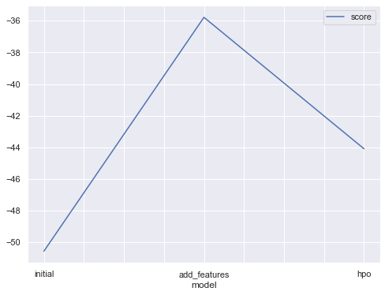

```python
# Taking the top model score from each training run and creating a line plot to show improvement
# You can create these in the notebook and save them to PNG or use some other tool (e.g. google sheets, excel)
fig = pd.DataFrame(
    {
        "model": ["initial", "add_features", "hpo"],
        "score": [-50.569302, -35.780223, -44.094050]
    }
).plot(x="model", y="score", figsize=(8, 6)).get_figure()
fig.savefig('model_train_score.png')
```

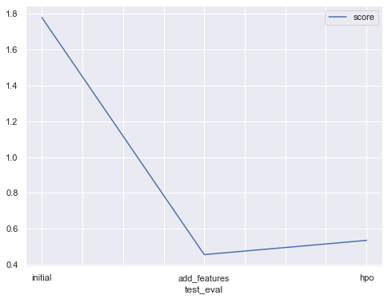

```python
# Take the 3 kaggle scores and creating a line plot to show improvement
fig = pd.DataFrame(
    {
        "test_eval": ["initial", "add_features", "hpo"],
        "score": [1.77919, 0.45618, 0.53554]
    }
).plot(x="test_eval", y="score", figsize=(8, 6)).get_figure()
fig.savefig('model_test_score.png')
```

### Hyperparameter table

```python
# The 3 hyperparameters we tuned with the kaggle score as the result
pd.DataFrame({
    "model": ["initial", "add_features", "hpo"],
    "timelimit": ["time_limit = 600", "time_limit=600", "time_limit=600"],
    "presets": ["presets='best_quality'", "presets='best_quality'", "presets='best_quality'"],
    "HyperParameters": ["none", "Feature manipulation", "NN and LightGBM"],
    "score": [1.77919, 0.45618, 0.53554]
})
```

|  | model | timelimit | presets | HyperParameters | score |
| --- | --- | --- | --- | --- | --- |
| 0 | initial | time_limit = 600 | presets='best_quality' | none | 1.77919 |
| 1 | add_features | time_limit=600 | presets='best_quality' | Feature manipulation | 0.45618 |
| 2 | hpo | time_limit=600 | presets='best_quality' | NN and LightGBM | 0.53554 |